# Week 11: Managing resources from afar via APIs

2020-03-30 08:57:32

## Preliminaries

## Check-in

## Announcements

## Today’s topics

- Managing resources from afar via APIs

## Managing resources from afar via APIs

## What are APIs

- Application Program Interface (API)
- Talk to computer services

## Why use APIs

- Reduce human manipulation of data files
- Reduce errors
- Reduce security/privacy breaches
- Improve reproducibility

[figure not shown]

[Munafo et al.](https://doi.org/10.1038/s41562-016-0021)

## Some useful APIs

- Box
- Google Drive
- OSF
- Databrary

## Box.com

- [`boxr` R package](https://r-box.github.io/boxr/)
- [`python-box` Python package](https://pypi.org/project/python-box/)

## Google Drive

- [`googledrive` R package](https://googledrive.tidyverse.org/)
- [`google-api-python-client` Python client](https://github.com/googleapis/google-api-python-client)

## Databrary

- [`databraryapi` R package](https://github.com/PLAY-behaviorome/databraryapi)
- [`databrarypi` Python package](https://github.com/PLAY-behaviorome/databrarypi)

## What can you do with these APIs?

- Move data to/from cloud storage
- Leave data on cloud storage; clean, visualize locally
- Produce reproducible workflows from the get-go
- Reduce the likelihood that data can “leak”
- Access & visualize data shared by others

## What’s involved?

- Downloading package
- Configuring authentication
- Testing the connection
- Writing code to do what you want

## Example 1: `databraryapi`

- Summarize demographics of specific study

Tamis-LeMonda, C. (2013). Language, cognitive, and socio-emotional skills from 9 months until their transition to first grade in U.S. children from African-American, Dominican, Mexican, and Chinese backgrounds. *Databrary*. Retrieved March 29, 2020 from http://doi.org/10.17910/B7CC74.

- Login

```r
databraryapi::login_db()
```

```
## Please enter your Databrary user ID (email).
```

```
## Email:
```

```
## [1] FALSE
```

- Download demographic data

```r
demog <- databraryapi::download_session_csv(8)
```

```r
str(demog)
```

```
## 'data.frame':    1351 obs. of  36 variables:
##  $ session_id           : int  190 191 192 193 194 195 196 197 198 199 ...
##  $ session_name         : logi  NA NA NA NA NA NA ...
##  $ session_date         : chr  "2006-XX-XX" "2006-XX-XX" "2006-XX-XX" "2006-XX-XX" ...
##  $ session_release      : chr  "EXCERPTS" "PRIVATE" "EXCERPTS" "PRIVATE" ...
##  $ participant.ID       : int  3814 3811 3808 3806 3804 3803 3801 3800 3797 3796 ...
##  $ participant.birthdate: logi  NA NA NA NA NA NA ...
##  $ participant.gender   : chr  "Male" "Female" "Female" "Male" ...
##  $ participant.race     : chr  "Black or African American" "Black or African American" "Black or African American" "Black or African American" ...
##  $ participant.ethnicity: chr  "Dominican" "Dominican" "Dominican" "Unknown or not reported" ...
##  $ participant.language : chr  "English" "English" "English" "English" ...
##  $ group.name           : chr  "14 month" "14 month" "14 month" "14 month" ...
##  $ task1.name           : chr  "Novel toy: string with beads" "Novel toy: string with beads" "Novel toy: string with beads" "Novel toy: string with beads" ...
##  $ task1.description    : chr  "Mother-child play with beads and string\nMother-child dyads played with beads and string." "Mother-child play with beads and string\nMother-child dyads played with beads and string." "Mother-child play with beads and string\nMother-child dyads played with beads and…
##  $ task2.name           : chr  "Mother-child free play" "Mother-child free play" "Mother-child free play" "Mother-child free play" ...
```

[output cut: 22 more lines]

- Clean and visualize

```r
sex_race <- demog %>%
  dplyr::select(., sex = participant.gender,
                race = participant.race)

xtabs(formula = ~ sex + race, sex_race)
```

```
##         race
## sex          Asian Black or African American Unknown or not reported White
##            7     0                         0                       0     0
##   Female   0   112                       341                       4   209
##   Male     0   111                       410                       2   155
```

## Other working examples

- [Quality Assurance (QA)](https://github.com/PLAY-behaviorome/workflow/tree/master/session_qa_reports) on PLAY
- Databrary [weekly report](https://gilmore-lab.github.io/databrary-analytics/weekly/databrary_weekly_report.html)

## Example 2: NY Times data on COVID-19

- Data: https://github.com/nytimes/covid-19-data
- NY tracking page: https://www.nytimes.com/interactive/2020/us/coronavirus-us-cases.html

```r
# Note the URL uses raw.githubusercontent.com
cv19 <- readr::read_csv("https://raw.githubusercontent.com/nytimes/covid-19-data/master/us-states.csv")
str(cv19)
```

```
## Classes 'spec_tbl_df', 'tbl_df', 'tbl' and 'data.frame': 1437 obs. of  5 variables:
##  $ date  : Date, format: "2020-01-21" "2020-01-22" ...
##  $ state : chr  "Washington" "Washington" "Washington" "Illinois" ...
##  $ fips  : chr  "53" "53" "53" "17" ...
##  $ cases : num  1 1 1 1 1 1 1 1 1 2 ...
##  $ deaths: num  0 0 0 0 0 0 0 0 0 0 ...
##  - attr(*, "spec")=
##   .. cols(
##   ..   date = col_date(format = ""),
##   ..   state = col_character(),
##   ..   fips = col_character(),
##   ..   cases = col_double(),
##   ..   deaths = col_double()
##   .. )
```

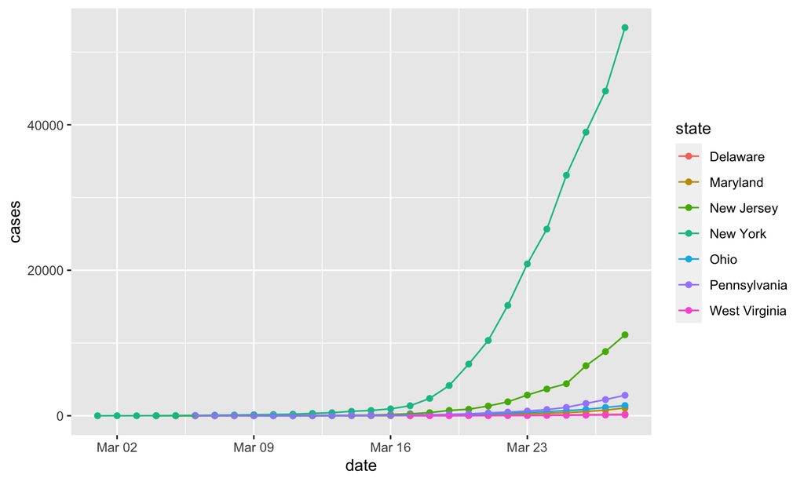

```r
cv19 %>%
  dplyr::filter(., state %in% c("Pennsylvania", "New York", "New Jersey", "Maryland", "Ohio", "West Virginia", "Delaware")) %>%
  ggplot(.) +
  aes(date, cases, color = state) +
  geom_point() +
  geom_line()
```

## Your turn

## Connect to Qualtrics

- how_to/interact-with-qualtrics

## Connect to Box

- how_to/interact-with-box

## Connect to Google Drive

- how_to/interact-with-google-drive

## Next time…

- Where to share
- Your open science portfolio